# Classification of the MNIST handwritten digits using CNNs

In this notebook we will do the following steps in order:

1. Load and normalizing the MNIST training and test datasets using torchvision
2. Define a Neural Network (simple fully connected at first, CNN later)
3. Define a loss function
4. Train the network on the training split of MNIST
5. Test the network on the test split of MNIST

## Install Pytorch to Colab VM

[Pytorch](https://pytorch.org) is a deep learning framework that allows you to build, train and evaluate various deep learning models, such as CNNs that we are going to work with in this project.

```python
import os
import sys
print("Python version: {}".format(sys.version_info[0]))

import warnings
warnings.filterwarnings('ignore') # to suppress unnecessary warnings

try:
    import torch
    print("PyTorch is already installed, good to go!")
except:
    from wheel.pep425tags import get_abbr_impl, get_impl_ver, get_abi_tag
    platform = '{}{}-{}'.format(get_abbr_impl(), get_impl_ver(), get_abi_tag())
    accelerator = 'cu80' if os.path.exists('/opt/bin/nvidia-smi') else 'cpu'
    !pip install -q \
      http://download.pytorch.org/whl/{accelerator}/torch-0.4.1-{platform}-linux_x86_64.whl \
      torchvision
    print("Successfully installed PyTorch!")
    import torch
```

```
Python version: 3
PyTorch is already installed, good to go!
```

## Some imports and setup

```python
import torch
import torch.nn as nn
import torch.nn.functional as F
import torch.optim as optim
import torchvision
from torchvision import datasets, transforms

import matplotlib.pyplot as plt  # for plots
import numpy as np  # for working with numbers and arrays of numbers

use_cuda = torch.cuda.is_available()
device = torch.device("cuda" if use_cuda else "cpu")
kwargs = {'num_workers': 1, 'pin_memory': True} if use_cuda else {}

import random
seed = 1
random.seed(seed)
torch.manual_seed(seed)
torch.cuda.manual_seed(seed)
np.random.seed(seed)
print("Setup is done!")
```

```
Setup is done!
```

# 1. Load MNIST data

Loading the data into your python script can be a tedious process. Luckily, PyTorch allows us to load the data using the torchvision.datasets classes. It has some of the popular datasets loading proccesses written for you, including the MNIST dataset. The data will be downloaded to the mnist_dir folder on the virtual machine if you run this cell for the first time.

## Iterating through the dataset

Let’s put this all together to create a dataset with composed transforms. Every time this dataset is sampled:

- An image is read from the file on the fly
- Transforms are applied on the read image
- We can iterate over the created dataset with a for i in range loop.

```python
mnist_dir = 'datasets/MNIST' # the directory our data will be downloaded too

transformed_dataset = datasets.MNIST(mnist_dir, train=True, download=True,
                       transform=transforms.Compose([
                           transforms.ToTensor(),
                           transforms.Normalize((0.1307,), (0.3081,)) # normalizing to the [-1,1] range
                       ]))

for i in range(len(transformed_dataset)):
    sample = transformed_dataset[i]

    print(i, sample[0].size(), sample[1].size())

    if i == 3:
        break
```

```
Downloading http://yann.lecun.com/exdb/mnist/train-images-idx3-ubyte.gz
Downloading http://yann.lecun.com/exdb/mnist/train-labels-idx1-ubyte.gz
Downloading http://yann.lecun.com/exdb/mnist/t10k-images-idx3-ubyte.gz
Downloading http://yann.lecun.com/exdb/mnist/t10k-labels-idx1-ubyte.gz
Processing...
Done!
0 torch.Size([1, 28, 28]) torch.Size([])
1 torch.Size([1, 28, 28]) torch.Size([])
2 torch.Size([1, 28, 28]) torch.Size([])
3 torch.Size([1, 28, 28]) torch.Size([])
```

However, we are losing a lot of features by using a simple for loop to iterate over the data. In particular, we are missing out on:

- Batching the data - images can be processed in bulk instead of one-by-one
- Shuffling the data - this is a useful technique of rearranging the order of the images in which our training algorithm will pick images
- Load the data in parallel using multiprocessing workers.

`torch.utils.data.DataLoader` is an iterator which provides all these features. In the code below we create 2 `DataLoader` objects, one for the training data, and one for the test data

To summarize, in order to load the data using PyTorch methods we need to:

1. Apply the necessary transforms to the image, in order to make it the same size as the rest and normalized
2. Create the `Dataset` object containing the methods to sample a training image
3. Create the `DataLoader` object for us to easier iterate over data

```python
def load_MNIST(mnist_dir, batch_size, test_batch_size, kwargs):

  # Dataloader object is used to organize training data neatly into batches
  # it is a part of the PyTorch framework
  train_loader = torch.utils.data.DataLoader(
        datasets.MNIST(mnist_dir, train=True, download=True,
                       transform=transforms.Compose([
                           transforms.ToTensor(),
                           transforms.Normalize((0.1307,), (0.3081,))
                       ])),
        batch_size=batch_size, shuffle=True, **kwargs)
  test_loader = torch.utils.data.DataLoader(
        datasets.MNIST(mnist_dir, train=False, transform=transforms.Compose([
                           transforms.ToTensor(),
                           transforms.Normalize((0.1307,), (0.3081,))
                       ])),
        batch_size=test_batch_size, shuffle=True, **kwargs)

  return train_loader, test_loader


batch_size = 50
test_batch_size = 100
mnist_dir = 'datasets/MNIST' # the directory our data will be downloaded too
train_loader, test_loader = load_MNIST(mnist_dir, batch_size, test_batch_size, kwargs)
print("The MNIST data is loaded successfully!")
```

```
The MNIST data is loaded successfully!
```

## Look at the data

We will sample a small subset of the training data to see what the MNIST data roughly looks like

```
One minibatch of MNIST data is a 4D array of shape torch.Size([50, 1, 28, 28])
1st dimension (50) is the number of images in the minibatch
2nd dimension (1) is the number of image channels
3rd and 4th dimensions (28, 28) are the spatial size of the image
```

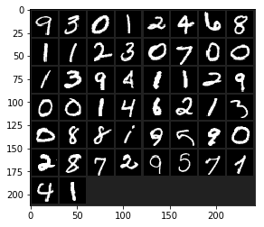

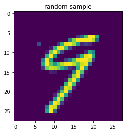

```python
# this function is here to show an image
def imshow(img, title=None):
    npimg = img.numpy()
    mean = np.array([0.1307])
    std = np.array([0.3081])
    npimg = std * npimg + mean # unnormalize
    npimg = np.clip(npimg, 0, 1)
    npimg = np.transpose(npimg, (1, 2, 0))
    npimg = npimg.squeeze()
    plt.imshow(npimg)
    plt.show
    if title is not None:
        plt.title(title)
    plt.pause(0.001)  # pause a bit so that plots are updated


# get some random training images
dataiter = iter(train_loader)
images, labels = dataiter.next()
print("One minibatch of MNIST data is a 4D array of shape {}".format(images.shape))
print("1st dimension ({}) is the number of images in the minibatch".format(batch_size))
print("2nd dimension ({}) is the number of image channels".format(images.shape[1]))
print("3rd and 4th dimensions ({0}, {1}) are the spatial size of the image".format(*images.shape[-2:]))

# show images
imshow(torchvision.utils.make_grid(images))

# show one sample
for batch_idx, (data, target) in enumerate(train_loader):
  sample = data[0] # change number to any id in the batch
  imshow(sample, 'random sample')
  break
```

# 2. Define the neural network

## Fully connecter with 1 layer

The pixels are represented as a 1D vector of size 784 and fed into a fully connected network with 10 output neurons

[figure not shown]

### Softmax

We also use a softmax function to transfer scores (logits) into class probabilities. \ Entries are normalized -> sum up to 1

[figure not shown]

### Note:

The fully-connected layer can be constructed with a `nn.Linear` module, which accepts 2 parameters:

- `in_channels` - number of input neurons
- `out_channels` - number of output neurons For example, when we have 784 input neurons and 10 output neurons we can initialize our module the following way:

  ```
  nn.Linear(784,10)
  ```

```python
class simpleFC(nn.Module):
    def __init__(self, input_size=784, num_classes=10):
        # declaring operations
        super().__init__() # calling the inint method of the superclass (nn.Module)
        self.fc1 = nn.Linear(input_size, num_classes) # fully-connected layer

    def forward(self, x):
        # defines the forward pass
        x = x.view(-1, 784) # here we represent a MNIST image as a vector of pixels
        # 784 is the total number of pixels in a 28 by 28 image
        out = self.fc1(x) # weighted sum of input and network weights -> Wx+b, b - bias
        return F.log_softmax(out, dim=1) # return activations after softmax layer

model = simpleFC().to(device)
```

Here we just defined the forward function. The backward function (where gradients are computed) is automatically defined for us using autograd. Any of the Tensor operations can be used in the forward function.

# 3. Define a Loss Function and an Optimizer

## Loss? How cross-entropy loss is calculated?

Loss is a way to quantifying what it means to have a “good” classifier

[figure not shown]

**Note!!!** In Pytorch obtaining log-probabilities in a neural network is easily achieved by adding a `LogSoftmax` layer in the last layer of your network and using `NLLLoss` (The negative log likelihood loss) You may use `CrossEntropyLoss` instead, if you prefer not to add an extra layer.

## Optimizer

The simplest update rule used in practice is the Stochastic Gradient Descent (SGD). This method updates all the weights of the neural net after computing the loss on one batch of images. The SGD update rule, as well as other more complicated optimizers like Nesterov-SGD, Adam, RMSProp, etc, are implemented in the torch.optim module. All you need to do is to create an optimizer variable and call its `.step` method during training. This will automatically update the weights of your network after you have computed the gradients with the `loss.backward` call.

```python
# this will be the function we use later to calculate the cross entropy loss
#loss_function = nn.CrossEntropyLoss() # use this instead if you don't use softmax activations
loss_function = nn.NLLLoss()
optimizer = optim.SGD(model.parameters(), lr=0.001, momentum=0.9) # lr - learning rate
```

## How to choose your learning rate?

Hyperparameter - not-leranable parameter and picked manually in the begging of training \ Try and see what works best \

Check behavious:

1. Simple_FC with lr = 0.01, 0.001, 0.0001
2. Complex_FC with lr = 0.01, 0.001, 0.0001
3. CNN with lr = 0.1, 0.01

[figure not shown]

## What is momentum?

- running average of previous updates! Small oscillations

  `V = momentum*V + (1-momentum)*gradient_of_parameters`

[figure not shown]

Without Momentum ->

```
update = learning_rate * gradient_of_parameters
parameters = parameters - update
```

[figure not shown]

With Momentum

```
V = momentum*V + (1-momentum)*gradient_of_parameters
parameters = parameters - learning_rate * V
```

[figure not shown]

# 4. Train the network

```python
def train(model, device, train_loader, loss_function, optimizer, epoch):
    model.train()
    for batch_idx, (data, target) in enumerate(train_loader):
        data, target = data.to(device), target.to(device)
        # data has a batch of images
        # target is a batch of corresponding training labels
        optimizer.zero_grad() # initialize all the gradients with zeros
        output = model(data) # compute the network's predictions for the batch of images
        loss = loss_function(output, target) # here we calculate the loss value
        loss.backward() # compute the gradients for all the weights of the network automatically!
        optimizer.step() # here we actually update the network's weights
        if batch_idx % 100 == 0:
            print('Train Epoch: {} [{}/{} ({:.0f}%)]\tLoss: {:.6f}'.format(
                epoch, batch_idx * len(data), len(train_loader.dataset),
                100. * batch_idx / len(train_loader), loss.item()))
print('Training method loaded!')
```

```
Training method loaded!
```

```python
num_epochs = 5
for epoch in range(1, num_epochs + 1):
        train(model, device, train_loader, loss_function, optimizer, epoch)
print('Training finished')
```

```
Train Epoch: 1 [0/60000 (0%)]	Loss: 2.495384
Train Epoch: 1 [5000/60000 (8%)]	Loss: 0.483837
Train Epoch: 1 [10000/60000 (17%)]	Loss: 0.437294
Train Epoch: 1 [15000/60000 (25%)]	Loss: 0.379753
Train Epoch: 1 [20000/60000 (33%)]	Loss: 0.326257
Train Epoch: 1 [25000/60000 (42%)]	Loss: 0.374313
Train Epoch: 1 [30000/60000 (50%)]	Loss: 0.423109
Train Epoch: 1 [35000/60000 (58%)]	Loss: 0.421719
Train Epoch: 1 [40000/60000 (67%)]	Loss: 0.350872
Train Epoch: 1 [45000/60000 (75%)]	Loss: 0.424521
Train Epoch: 1 [50000/60000 (83%)]	Loss: 0.331740
Train Epoch: 1 [55000/60000 (92%)]	Loss: 0.361782
Train Epoch: 2 [0/60000 (0%)]	Loss: 0.389005
Train Epoch: 2 [5000/60000 (8%)]	Loss: 0.262778
Train Epoch: 2 [10000/60000 (17%)]	Loss: 0.217856
Train Epoch: 2 [15000/60000 (25%)]	Loss: 0.174293
Train Epoch: 2 [20000/60000 (33%)]	Loss: 0.487992
Train Epoch: 2 [25000/60000 (42%)]	Loss: 0.297962
Train Epoch: 2 [30000/60000 (50%)]	Loss: 0.392958
Train Epoch: 2 [35000/60000 (58%)]	Loss: 0.375605
Train Epoch: 2 [40000/60000 (67%)]	Loss: 0.313805
Train Epoch: 2 [45000/60000 (75%)]	Loss: 0.264075
Train Epoch: 2 [50000/60000 (83%)]	Loss: 0.159767
Train Epoch: 2 [55000/60000 (92%)]	Loss: 0.396580
Train Epoch: 3 [0/60000 (0%)]	Loss: 0.426782
Train Epoch: 3 [5000/60000 (8%)]	Loss: 0.372187
Train Epoch: 3 [10000/60000 (17%)]	Loss: 0.120743
Train Epoch: 3 [15000/60000 (25%)]	Loss: 0.340747
Train Epoch: 3 [20000/60000 (33%)]	Loss: 0.235703
Train Epoch: 3 [25000/60000 (42%)]	Loss: 0.278660
Train Epoch: 3 [30000/60000 (50%)]	Loss: 0.242275
Train Epoch: 3 [35000/60000 (58%)]	Loss: 0.291653
Train Epoch: 3 [40000/60000 (67%)]	Loss: 0.263292
Train Epoch: 3 [45000/60000 (75%)]	Loss: 0.293407
Train Epoch: 3 [50000/60000 (83%)]	Loss: 0.285518
Train Epoch: 3 [55000/60000 (92%)]	Loss: 0.230060
Train Epoch: 4 [0/60000 (0%)]	Loss: 0.252571
Train Epoch: 4 [5000/60000 (8%)]	Loss: 0.266983
Train Epoch: 4 [10000/60000 (17%)]	Loss: 0.317404
Train Epoch: 4 [15000/60000 (25%)]	Loss: 0.224143
Train Epoch: 4 [20000/60000 (33%)]	Loss: 0.514820
Train Epoch: 4 [25000/60000 (42%)]	Loss: 0.490459
Train Epoch: 4 [30000/60000 (50%)]	Loss: 0.233064
Train Epoch: 4 [35000/60000 (58%)]	Loss: 0.329790
Train Epoch: 4 [40000/60000 (67%)]	Loss: 0.482517
Train Epoch: 4 [45000/60000 (75%)]	Loss: 0.219054
Train Epoch: 4 [50000/60000 (83%)]	Loss: 0.367716
Train Epoch: 4 [55000/60000 (92%)]	Loss: 0.487500
Train Epoch: 5 [0/60000 (0%)]	Loss: 0.109560
Train Epoch: 5 [5000/60000 (8%)]	Loss: 0.305275
Train Epoch: 5 [10000/60000 (17%)]	Loss: 0.241793
Train Epoch: 5 [15000/60000 (25%)]	Loss: 0.254070
Train Epoch: 5 [20000/60000 (33%)]	Loss: 0.219412
Train Epoch: 5 [25000/60000 (42%)]	Loss: 0.210968
Train Epoch: 5 [30000/60000 (50%)]	Loss: 0.128079
Train Epoch: 5 [35000/60000 (58%)]	Loss: 0.238608
Train Epoch: 5 [40000/60000 (67%)]	Loss: 0.527638
Train Epoch: 5 [45000/60000 (75%)]	Loss: 0.155022
Train Epoch: 5 [50000/60000 (83%)]	Loss: 0.097836
Train Epoch: 5 [55000/60000 (92%)]	Loss: 0.194146
Training finished
```

# 5. Test on the remaining 10000 images

here we have a method to calculate how well our trained network can work on the images that it has not seen during training.

```python
def test(model, device, test_loader):
    model.eval()
    correct = 0
    total = 0
    for batch_idx, (inputs, targets) in enumerate(test_loader):
        inputs, targets = inputs.to(device), targets.to(device)
        outputs = model(inputs)
        _, predicted = torch.max(outputs.data, 1)
        total += targets.size(0)
        correct += (predicted == targets).sum().item()
        if batch_idx % 10 == 0:
            print('[{}/{}]\t'
                  'Correct: {}\t'
                  'Total: {}\t'.format(
                batch_idx,
                len(test_loader),
                correct,
                total))
    if len(test_loader.dataset)==0:
        print("Error: test data have not been loaded correctly")
        return -1

    accuracy = 100.0 * correct / total

    print('Accuracy of the network on the test images: {:.3f}%; correct: {} out of {}'.format(
        accuracy, correct, total))

print("Test method is loaded successfully")
```

```
Test method is loaded successfully
```

## Call the test function to get the accuracy of our model on the test data

```python
test(model, device, test_loader)
```

```
[0/100]	Correct: 91	Total: 100
[10/100]	Correct: 1010	Total: 1100
[20/100]	Correct: 1922	Total: 2100
[30/100]	Correct: 2834	Total: 3100
[40/100]	Correct: 3752	Total: 4100
[50/100]	Correct: 4667	Total: 5100
[60/100]	Correct: 5601	Total: 6100
[70/100]	Correct: 6535	Total: 7100
[80/100]	Correct: 7456	Total: 8100
[90/100]	Correct: 8383	Total: 9100
Accuracy of the network on the test images: 92.080%; correct: 9208 out of 10000
```

## How does optimization work?

[figure not shown]

# Now let's try other networks

## Convolutional net with 2 conv layers

### Conv2d

A convolutional layer in PyTorch can be created using the nn.Conv2d function. Here are its some essential parameters:

1. in_channels - depth of the input (D1)
2. out_channels - depth of the output (D2)
3. kernel_size - defines both height and with of the filter (F)
4. padding - set to 0 by default, which means no zero padding
5. stride - set to 1 by default

Example of initializing the conv2d module:

```
in_channels = 1
out_channels = 10
kernel_size = 5
nn.conv2d(in_channels, out_channels, kernel_size)
```

The function then can be called on the 4D input tensor of size nSamples x nChannels x Height x Width, which is one batch (nSamples) of images. The call happens in the `forward` method of our model

### Max pooling

It is common to periodically insert a Pooling layer in-between successive Conv layers in a ConvNet architecture. Its function is to progressively reduce the spatial size of the representation to reduce the amount of parameters and computation in the network, and hence to also control overfitting.

This is mainly done to fight overfitting and to lower the computational cost by reducing the number of parameters to learn. This also provides a basic translation invariance to the internal representation.

Max pooling is done by applying a max filter to (usually) non-overlapping subregions of the initial representation. The most commonly used is the 2x2 max filter applied with a stride S = 2:

[figure not shown]

### Note!

PyTorch `torch.nn.functional.max_pool2d` function has 2 required parameters:

- `input` - the input image or feature map
- `kernel_size` - the size of the max filter (we will use 2)

### In the following section we can check the shapes of different feature maps starting from the input 4D tensor (nSamples x nChannels x Height x Width) and going all the way to the output activations.

```python
class exampleCNN(nn.Module):
    def __init__(self):
        super().__init__()
        self.conv1 = nn.Conv2d(1, 10, kernel_size=5)  # first convolutional layer
        self.conv2 = nn.Conv2d(10, 20, kernel_size=5) # second convolutional layer
        self.fc1 = nn.Linear(20*4*4, 10) # fully connected layer

    def forward(self, x):
        print("Original input size:\t {}".format(x.shape))
        x = self.conv1(x)
        print("Size after conv1:\t {}".format(x.shape))
        x = F.max_pool2d(x, 2)
        print("Size after max pool 1:\t {}".format(x.shape))
        x = F.relu(x)
        x = self.conv2(x)
        print("Size after conv2:\t {}".format(x.shape))
        x = F.max_pool2d(x, 2)
        print("Size after max pool 2:\t {}".format(x.shape))
        x = F.relu(x)
        x = x.view(-1, 16*20)
        print("Size before fc1:\t {}".format(x.shape))
        x = self.fc1(x)
        print("Size after fc1:\t\t {}".format(x.shape))
        return F.log_softmax(x, dim=1)

example_model = exampleCNN().to(device)

batch = torch.stack((sample,)*1, 0) # just one image in a batch for example
batch.shape
example_model(batch)
```

```
Original input size:	 torch.Size([1, 1, 28, 28])
Size after conv1:	 torch.Size([1, 10, 24, 24])
Size after max pool 1:	 torch.Size([1, 10, 12, 12])
Size after conv2:	 torch.Size([1, 20, 8, 8])
Size after max pool 2:	 torch.Size([1, 20, 4, 4])
Size before fc1:	 torch.Size([1, 320])
Size after fc1:		 torch.Size([1, 10])
```

```
tensor([[-2.2987, -1.6621, -2.8336, -2.2006, -2.9512, -2.2760, -1.9808, -2.3428,
         -2.4806, -2.6933]], grad_fn=<LogSoftmaxBackward>)
```

### 2b. Define a CNN network

Now let's rewrite the same network without the `print` calls, so that they won't clutter our log when we are doing training

```python
class simpleCNN(nn.Module):
    def __init__(self):
        super(simpleCNN, self).__init__()
        self.conv1 = nn.Conv2d(1, 10, kernel_size=5)  # first convolutional layer
        self.conv2 = nn.Conv2d(10, 20, kernel_size=5) # second convolutional layer
        self.fc1 = nn.Linear(320, 10) # fully connected layer,
        # why the first parameter is set to 320??? Think about it

    def forward(self, x):
        x = self.conv1(x)
        x = F.max_pool2d(x, 2)
        x = F.relu(x)
        x = self.conv2(x)
        x = F.max_pool2d(x, 2)
        x = F.relu(x)
        x = x.view(-1, 320)
        x = self.fc1(x)
        return F.log_softmax(x, dim=1)

cnn_model = simpleCNN().to(device)
```

### 3b. Define the Loss and optimizer

### 4b. Train the network

```python
loss_function = nn.NLLLoss()
optimizer = optim.SGD(cnn_model.parameters(), lr=0.001, momentum=0.9) # lr - learning rate
num_epochs = 5
for epoch in range(1, num_epochs + 1):
        train(cnn_model, device, train_loader, loss_function, optimizer, epoch)
print('Training finished')
```

```
Train Epoch: 1 [0/60000 (0%)]	Loss: 0.146896
Train Epoch: 1 [5000/60000 (8%)]	Loss: 0.012856
Train Epoch: 1 [10000/60000 (17%)]	Loss: 0.073910
Train Epoch: 1 [15000/60000 (25%)]	Loss: 0.047947
Train Epoch: 1 [20000/60000 (33%)]	Loss: 0.040577
Train Epoch: 1 [25000/60000 (42%)]	Loss: 0.023476
Train Epoch: 1 [30000/60000 (50%)]	Loss: 0.051140
Train Epoch: 1 [35000/60000 (58%)]	Loss: 0.166916
Train Epoch: 1 [40000/60000 (67%)]	Loss: 0.026108
Train Epoch: 1 [45000/60000 (75%)]	Loss: 0.005224
Train Epoch: 1 [50000/60000 (83%)]	Loss: 0.106935
Train Epoch: 1 [55000/60000 (92%)]	Loss: 0.011023
Train Epoch: 2 [0/60000 (0%)]	Loss: 0.011139
Train Epoch: 2 [5000/60000 (8%)]	Loss: 0.064827
Train Epoch: 2 [10000/60000 (17%)]	Loss: 0.005050
Train Epoch: 2 [15000/60000 (25%)]	Loss: 0.064101
Train Epoch: 2 [20000/60000 (33%)]	Loss: 0.012161
Train Epoch: 2 [25000/60000 (42%)]	Loss: 0.040846
Train Epoch: 2 [30000/60000 (50%)]	Loss: 0.027635
Train Epoch: 2 [35000/60000 (58%)]	Loss: 0.022799
Train Epoch: 2 [40000/60000 (67%)]	Loss: 0.056130
Train Epoch: 2 [45000/60000 (75%)]	Loss: 0.193463
Train Epoch: 2 [50000/60000 (83%)]	Loss: 0.052373
Train Epoch: 2 [55000/60000 (92%)]	Loss: 0.066783
Train Epoch: 3 [0/60000 (0%)]	Loss: 0.009760
Train Epoch: 3 [5000/60000 (8%)]	Loss: 0.041697
Train Epoch: 3 [10000/60000 (17%)]	Loss: 0.026686
Train Epoch: 3 [15000/60000 (25%)]	Loss: 0.110647
Train Epoch: 3 [20000/60000 (33%)]	Loss: 0.012568
Train Epoch: 3 [25000/60000 (42%)]	Loss: 0.010722
Train Epoch: 3 [30000/60000 (50%)]	Loss: 0.011279
Train Epoch: 3 [35000/60000 (58%)]	Loss: 0.104865
Train Epoch: 3 [40000/60000 (67%)]	Loss: 0.073970
Train Epoch: 3 [45000/60000 (75%)]	Loss: 0.017448
Train Epoch: 3 [50000/60000 (83%)]	Loss: 0.073058
Train Epoch: 3 [55000/60000 (92%)]	Loss: 0.019785
Train Epoch: 4 [0/60000 (0%)]	Loss: 0.032007
Train Epoch: 4 [5000/60000 (8%)]	Loss: 0.123076
Train Epoch: 4 [10000/60000 (17%)]	Loss: 0.007190
Train Epoch: 4 [15000/60000 (25%)]	Loss: 0.029870
Train Epoch: 4 [20000/60000 (33%)]	Loss: 0.013847
Train Epoch: 4 [25000/60000 (42%)]	Loss: 0.012447
Train Epoch: 4 [30000/60000 (50%)]	Loss: 0.037190
Train Epoch: 4 [35000/60000 (58%)]	Loss: 0.069047
Train Epoch: 4 [40000/60000 (67%)]	Loss: 0.020425
Train Epoch: 4 [45000/60000 (75%)]	Loss: 0.027150
Train Epoch: 4 [50000/60000 (83%)]	Loss: 0.117244
Train Epoch: 4 [55000/60000 (92%)]	Loss: 0.013817
Train Epoch: 5 [0/60000 (0%)]	Loss: 0.037934
Train Epoch: 5 [5000/60000 (8%)]	Loss: 0.008292
Train Epoch: 5 [10000/60000 (17%)]	Loss: 0.012590
Train Epoch: 5 [15000/60000 (25%)]	Loss: 0.071868
Train Epoch: 5 [20000/60000 (33%)]	Loss: 0.008087
Train Epoch: 5 [25000/60000 (42%)]	Loss: 0.041770
Train Epoch: 5 [30000/60000 (50%)]	Loss: 0.018796
Train Epoch: 5 [35000/60000 (58%)]	Loss: 0.102281
Train Epoch: 5 [40000/60000 (67%)]	Loss: 0.026473
Train Epoch: 5 [45000/60000 (75%)]	Loss: 0.018503
Train Epoch: 5 [50000/60000 (83%)]	Loss: 0.018887
Train Epoch: 5 [55000/60000 (92%)]	Loss: 0.034738
Training finished
```

### 5b. and test it to get the final accuracy

```python
test(cnn_model, device, test_loader)
```

```
[0/100]	Correct: 98	Total: 100
[10/100]	Correct: 1087	Total: 1100
[20/100]	Correct: 2073	Total: 2100
[30/100]	Correct: 3054	Total: 3100
[40/100]	Correct: 4038	Total: 4100
[50/100]	Correct: 5026	Total: 5100
[60/100]	Correct: 6013	Total: 6100
[70/100]	Correct: 6997	Total: 7100
[80/100]	Correct: 7985	Total: 8100
[90/100]	Correct: 8973	Total: 9100
Accuracy of the network on the test images: 98.620%; correct: 9862 out of 10000
```

## [Optional] Your beast network that will get more than 99% accuracy on the test split

Your code here! Modify the method below. You can start with the suggested code or rewrite your own.

```python
class CNN(nn.Module):
    def __init__(self):
        ########################################################################
        # modify code here:
        super(CNN, self).__init__()
        self.conv1 = nn.Conv2d(1, 32, kernel_size=3, padding=1)  # first convolutional layer
        self.conv2 = nn.Conv2d(32, 32, kernel_size=3, padding=1) # second convolutional layer
        self.conv3 = nn.Conv2d(32, 64, kernel_size=3, padding=1)
        self.conv4 = nn.Conv2d(64, 64, kernel_size=3, padding=1)
        self.fc1 = nn.Linear(64*7*7, 512) # fully connected layer 1
        self.fc2 = nn.Linear(512, 512) # fully connected layer 2
        self.fc3 = nn.Linear(512, 10)
        self.bn1 = nn.BatchNorm2d(32)
        self.bn2 = nn.BatchNorm2d(32)
        self.bn3 = nn.BatchNorm2d(64)
        self.bn4 = nn.BatchNorm2d(64)
        self.bn5 = nn.BatchNorm1d(512)
        self.bn6 = nn.BatchNorm1d(512)
        ########################################################################

    def forward(self, x):
        ########################################################################
        # modify code here:
        x = self.conv1(x)
        x = self.bn1(x)
        x = F.relu(x)
        x = self.conv2(x)
        x = self.bn2(x)
        x = F.relu(x)
        x = F.max_pool2d(x, 2)
        x = self.conv3(x)
        x = self.bn3(x)
        x = F.relu(x)
        x = self.conv4(x)
        x = self.bn4(x)
        x = F.relu(x)
        x = F.max_pool2d(x, 2)
        x = F.dropout(x)
        x = x.view(-1, 64*7*7)
        x = self.fc1(x)
        x = self.bn5(x)
        x = F.relu(x)
        x = F.dropout(x)
        x = self.fc2(x)
        x = self.bn6(x)
        x = F.relu(x)
        x = F.dropout(x)
        x = self.fc3(x)
        ########################################################################
        return F.log_softmax(x, dim=1)

cnn_model_2 = CNN().to(device)
```

### 3c. Define a Loss and an Optimizer

### 4c. Train the network

```python
loss_function = nn.NLLLoss()
optimizer = optim.Adam(cnn_model_2.parameters(), lr=0.003) # lr - learning rate
num_epochs = 5
for epoch in range(1, num_epochs + 1):
        train(cnn_model_2, device, train_loader, loss_function, optimizer, epoch)
print('Training finished')
```

```
Train Epoch: 1 [0/60000 (0%)]	Loss: 0.002971
Train Epoch: 1 [5000/60000 (8%)]	Loss: 0.002103
Train Epoch: 1 [10000/60000 (17%)]	Loss: 0.080375
Train Epoch: 1 [15000/60000 (25%)]	Loss: 0.004312
Train Epoch: 1 [20000/60000 (33%)]	Loss: 0.013984
Train Epoch: 1 [25000/60000 (42%)]	Loss: 0.021927
Train Epoch: 1 [30000/60000 (50%)]	Loss: 0.015353
Train Epoch: 1 [35000/60000 (58%)]	Loss: 0.013339
Train Epoch: 1 [40000/60000 (67%)]	Loss: 0.051983
Train Epoch: 1 [45000/60000 (75%)]	Loss: 0.033669
Train Epoch: 1 [50000/60000 (83%)]	Loss: 0.031852
Train Epoch: 1 [55000/60000 (92%)]	Loss: 0.017887
Train Epoch: 2 [0/60000 (0%)]	Loss: 0.009122
Train Epoch: 2 [5000/60000 (8%)]	Loss: 0.006382
Train Epoch: 2 [10000/60000 (17%)]	Loss: 0.023941
Train Epoch: 2 [15000/60000 (25%)]	Loss: 0.006403
Train Epoch: 2 [20000/60000 (33%)]	Loss: 0.017887
Train Epoch: 2 [25000/60000 (42%)]	Loss: 0.001551
Train Epoch: 2 [30000/60000 (50%)]	Loss: 0.007749
Train Epoch: 2 [35000/60000 (58%)]	Loss: 0.085137
Train Epoch: 2 [40000/60000 (67%)]	Loss: 0.010380
Train Epoch: 2 [45000/60000 (75%)]	Loss: 0.125484
Train Epoch: 2 [50000/60000 (83%)]	Loss: 0.012200
Train Epoch: 2 [55000/60000 (92%)]	Loss: 0.008173
Train Epoch: 3 [0/60000 (0%)]	Loss: 0.001910
Train Epoch: 3 [5000/60000 (8%)]	Loss: 0.003907
Train Epoch: 3 [10000/60000 (17%)]	Loss: 0.002687
Train Epoch: 3 [15000/60000 (25%)]	Loss: 0.027342
Train Epoch: 3 [20000/60000 (33%)]	Loss: 0.005483
Train Epoch: 3 [25000/60000 (42%)]	Loss: 0.007117
Train Epoch: 3 [30000/60000 (50%)]	Loss: 0.003055
Train Epoch: 3 [35000/60000 (58%)]	Loss: 0.016762
Train Epoch: 3 [40000/60000 (67%)]	Loss: 0.001408
Train Epoch: 3 [45000/60000 (75%)]	Loss: 0.033524
Train Epoch: 3 [50000/60000 (83%)]	Loss: 0.021311
Train Epoch: 3 [55000/60000 (92%)]	Loss: 0.007158
Train Epoch: 4 [0/60000 (0%)]	Loss: 0.010710
Train Epoch: 4 [5000/60000 (8%)]	Loss: 0.004855
Train Epoch: 4 [10000/60000 (17%)]	Loss: 0.001972
Train Epoch: 4 [15000/60000 (25%)]	Loss: 0.002093
Train Epoch: 4 [20000/60000 (33%)]	Loss: 0.005709
Train Epoch: 4 [25000/60000 (42%)]	Loss: 0.077644
Train Epoch: 4 [30000/60000 (50%)]	Loss: 0.000282
Train Epoch: 4 [35000/60000 (58%)]	Loss: 0.025622
Train Epoch: 4 [40000/60000 (67%)]	Loss: 0.000384
Train Epoch: 4 [45000/60000 (75%)]	Loss: 0.044862
Train Epoch: 4 [50000/60000 (83%)]	Loss: 0.007851
Train Epoch: 4 [55000/60000 (92%)]	Loss: 0.203622
Train Epoch: 5 [0/60000 (0%)]	Loss: 0.069173
Train Epoch: 5 [5000/60000 (8%)]	Loss: 0.000114
Train Epoch: 5 [10000/60000 (17%)]	Loss: 0.076563
Train Epoch: 5 [15000/60000 (25%)]	Loss: 0.065803
Train Epoch: 5 [20000/60000 (33%)]	Loss: 0.001963
Train Epoch: 5 [25000/60000 (42%)]	Loss: 0.000498
Train Epoch: 5 [30000/60000 (50%)]	Loss: 0.013656
Train Epoch: 5 [35000/60000 (58%)]	Loss: 0.001962
Train Epoch: 5 [40000/60000 (67%)]	Loss: 0.000983
Train Epoch: 5 [45000/60000 (75%)]	Loss: 0.000370
Train Epoch: 5 [50000/60000 (83%)]	Loss: 0.013748
Train Epoch: 5 [55000/60000 (92%)]	Loss: 0.001644
Training finished
```

### 5c. and test it

```python
test(cnn_model_2, device, test_loader)
```

```
[0/100]	Correct: 98	Total: 100
[10/100]	Correct: 1089	Total: 1100
[20/100]	Correct: 2082	Total: 2100
[30/100]	Correct: 3075	Total: 3100
[40/100]	Correct: 4069	Total: 4100
[50/100]	Correct: 5065	Total: 5100
[60/100]	Correct: 6054	Total: 6100
[70/100]	Correct: 7046	Total: 7100
[80/100]	Correct: 8037	Total: 8100
[90/100]	Correct: 9033	Total: 9100
Accuracy of the network on the test images: 99.230%; correct: 9923 out of 10000
```